# Cognitive Differences in Reward Processing between ADHD and Neurotypical Children

2024-12-03

## Research Objective

- How does reward processing differ between children diagnosed with ADHD and neurotypical children?

## Fork Question

- How does the timing and accuracy of responses during reward trials in the n-back task differ between children with ADHD and neurotypical children?

## Data Source

- Public datasets accessed from OpenNeuro.org: https://openneuro.org/datasets/ds002424/versions/1.2.0

## Method

- Participants: Children with ADHD (5) and neurotypical children (5)
- Experiment: Participants performed an n-back task, identifying whether a letter matched either by identity (verbal) or location (spatial)
  - Conditions: Small vs. large rewards and immediate vs. delayed feedback
  - Responses: Accuracy and timing of button-box presses analyzed during reward trials to compare groups
- Design: Block design alternating between experimental (1-back, 2-back) and fixation blocks.

## Figure 1

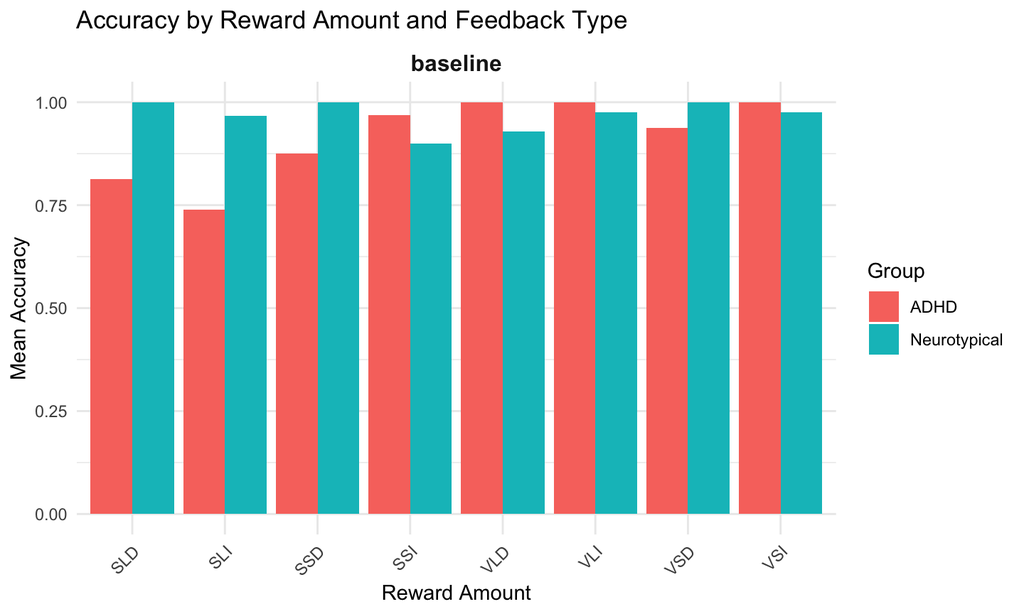

## Figure 2

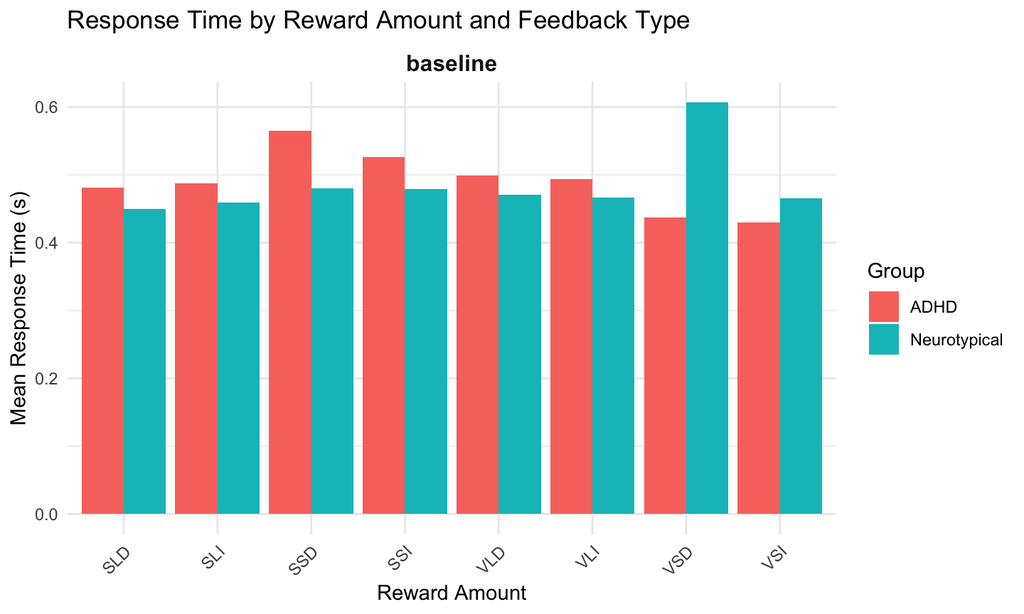

## What does this mean?

- ADHD and neurotypical groups exhibit distinct patterns in terms of both the accuracy and timing of their responses during the n-back task, especially when the task involves varying reward amounts and feedback.
- Could imply differences in cognitive processing speed and decision-making when rewards are involved.